# Week 1: Dissecting the Linear & Logistic Regression Models

Xuan Pham

2017-03-14

# Required R Packages

Install these two packages into your machine: **car** and **corrplot**.

# Supervised Learning

Basic terms:

Target Variable|Dependent Variable: the variable whose values we want to predict/model

Predictor Variable|Independent Variable|Feature: the variable(s) we use to predict/model the target or dependent variable

Linear regression is a supervised learning algorithm.

# Goal

Our goal is predict a person’s wage and salary earning. We are given eight predictors.

# Data

Our dataset contains all civilian persons who were sampled for the March Supplement of the 2014 Current Population Survey (CPS) and earned $200,000 or less in wage and salary. Here is more information about the CPS: https://en.wikipedia.org/wiki/Current_Population_Survey_(US)

```r
CPS<-read.csv(file="C:/Users/PhamX/Courses/Spring_2017/BIA_6301/Module_1/data/March_CPS_2014.csv")
```

# Viewing the Data Frame

```r
str(CPS)
```

```
## 'data.frame':    60314 obs. of  9 variables:
##  $ Years.of.Education                : int  20 16 16 9 12 16 12 16 16 12 ...
##  $ Years.of.Potential.Work.Experience: int  48 51 13 2 26 26 38 17 18 22 ...
##  $ Class.of.Worker                   : Factor w/ 6 levels "Federal Govt",..: 6 3 3 3 3 3 3 4 4 3 ...
##  $ Census.Region                     : Factor w/ 9 levels "East North Central",..: 5 5 5 5 5 5 5 5 5 5 ...
##  $ Work.Status                       : Factor w/ 2 levels "Full-time","Part-time": 1 1 1 2 1 1 1 1 1 1 ...
##  $ Wage.and.Salary                   : int  15000 42000 29000 2400 35000 35000 50000 40000 57000 34000 ...
##  $ Industry.of.Work                  : Factor w/ 13 levels "Agriculture",..: 11 4 4 2 7 7 8 13 6 7 ...
##  $ Child.Under.18                    : Factor w/ 2 levels "No","Yes": 2 2 2 2 2 1 1 2 2 2 ...
##  $ Sex                               : Factor w/ 2 levels "Female","Male": 2 1 1 1 2 2 1 1 2 2 ...
```

```r
summary(CPS)
```

```
##  Years.of.Education Years.of.Potential.Work.Experience
##  Min.   : 0.00      Min.   :-10.00
##  1st Qu.:12.00      1st Qu.: 11.00
##  Median :13.00      Median : 22.00
##  Mean   :13.75      Mean   : 22.79
##  3rd Qu.:16.00      3rd Qu.: 33.00
##  Max.   :20.00      Max.   : 75.00
##
##                        Class.of.Worker             Census.Region
##  Federal Govt                  : 1792   South Atlantic    :10881
##  Local Govt                    : 4669   Pacific           : 9663
##  Private                       :48025   West North Central: 7269
##  Self Employed Incorporated    : 2208   East North Central: 6772
##  Self Employed Not Incorporated:  575   Mountain          : 6456
##  State Govt                    : 3045   New England       : 5749
##                                         (Other)           :13524
##     Work.Status    Wage.and.Salary
##  Full-time:48840   Min.   :     2
##  Part-time:11474   1st Qu.: 18000
##                    Median : 35000
##                    Mean   : 42697
##                    3rd Qu.: 58000
##                    Max.   :200000
##
##                                                Industry.of.Work
##  Educational, Health, and Social Services              :14124
##  Wholesale or Retail Trade                             : 8444
##  Manufacturing                                         : 6419
##  Professional, Scientific, Management, Administration  : 6277
##  Arts, Entertainment, Recreation, Accommodation        : 5929
##  Financial, Insurance, Real Estate, Rental, and Leasing: 3942
##  (Other)                                               :15179
##  Child.Under.18     Sex
##  No :29848      Female:29247
##  Yes:30466      Male  :31067
##
##
##
##
##
```

```r
dim(CPS)
```

```
## [1] 60314     9
```

```r
names(CPS)
```

```
## [1] "Years.of.Education"
## [2] "Years.of.Potential.Work.Experience"
## [3] "Class.of.Worker"
## [4] "Census.Region"
## [5] "Work.Status"
## [6] "Wage.and.Salary"
## [7] "Industry.of.Work"
## [8] "Child.Under.18"
## [9] "Sex"
```

# Visualizing the Data

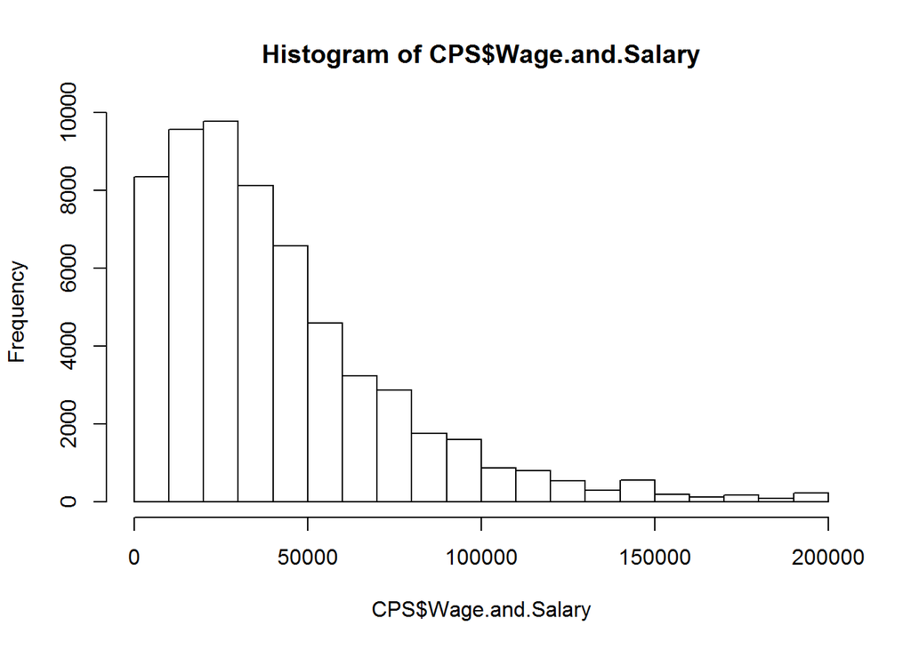

```r
hist(CPS$Wage.and.Salary)
```

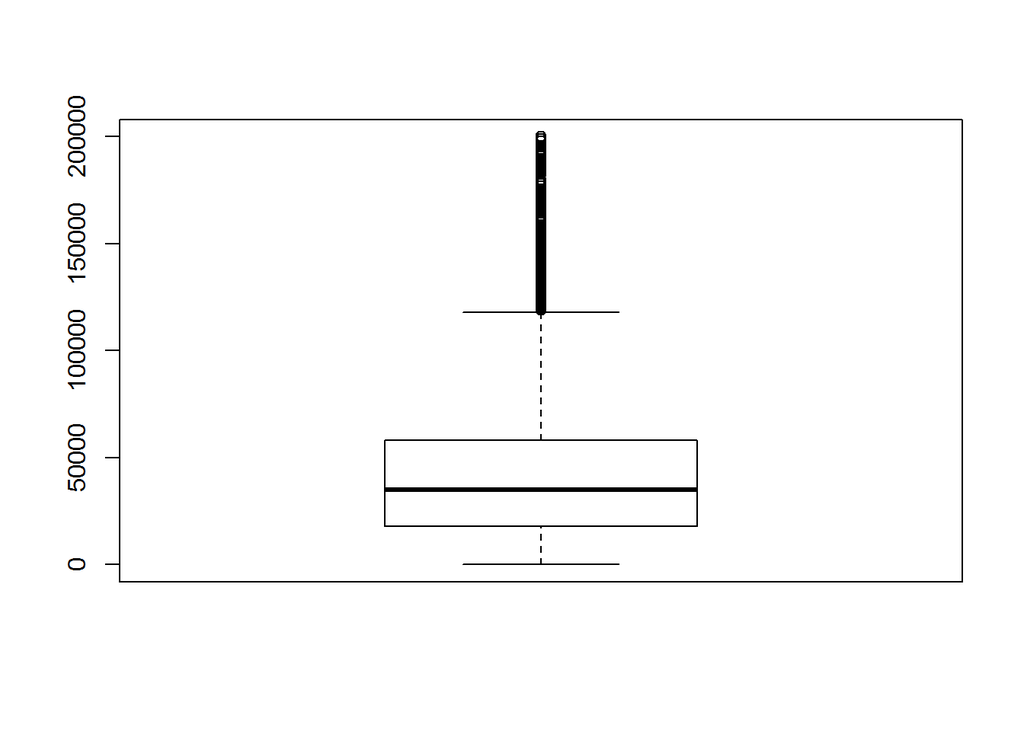

```r
boxplot(CPS$Wage.and.Salary)
```

```r
count_Class.of.Worker<-table(CPS$Class.of.Worker)
count_Class.of.Worker
```

```
##
##                   Federal Govt                     Local Govt
##                           1792                           4669
##                        Private     Self Employed Incorporated
##                          48025                           2208
## Self Employed Not Incorporated                     State Govt
##                            575                           3045
```

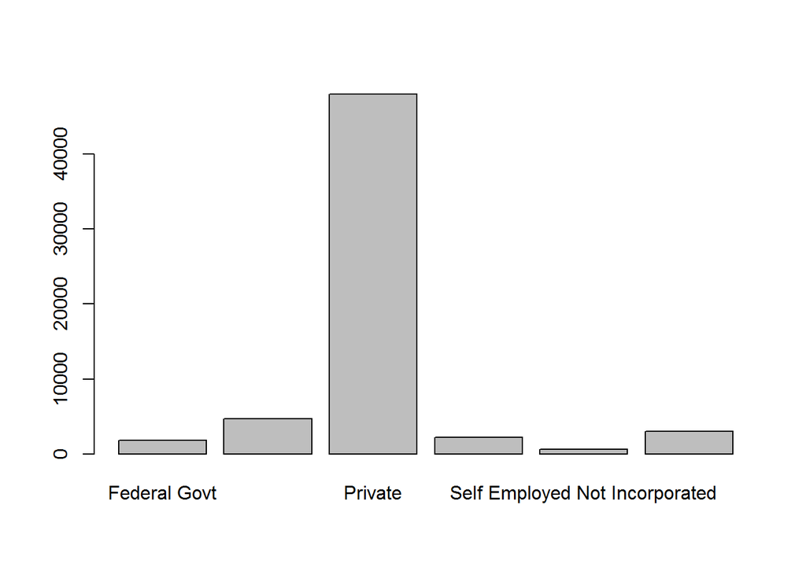

```r
barplot(count_Class.of.Worker)
```

```r
Numeric_Vars <-CPS[,c(1:2,6)]
Correlation_Matrix <- cor(Numeric_Vars)
Correlation_Matrix
```

```
##                                    Years.of.Education
## Years.of.Education                          1.0000000
## Years.of.Potential.Work.Experience         -0.1113609
## Wage.and.Salary                             0.4260810
##                                    Years.of.Potential.Work.Experience
## Years.of.Education                                         -0.1113609
## Years.of.Potential.Work.Experience                          1.0000000
## Wage.and.Salary                                             0.1505001
##                                    Wage.and.Salary
## Years.of.Education                       0.4260810
## Years.of.Potential.Work.Experience       0.1505001
## Wage.and.Salary                          1.0000000
```

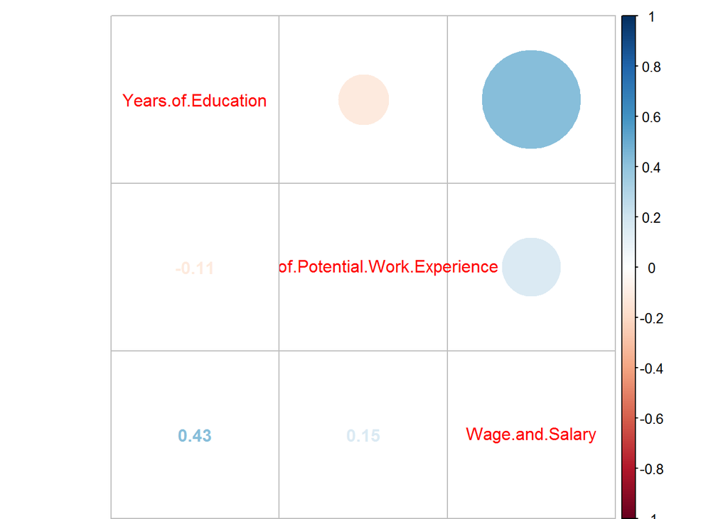

```r
library(corrplot)
corrplot.mixed(Correlation_Matrix)
```

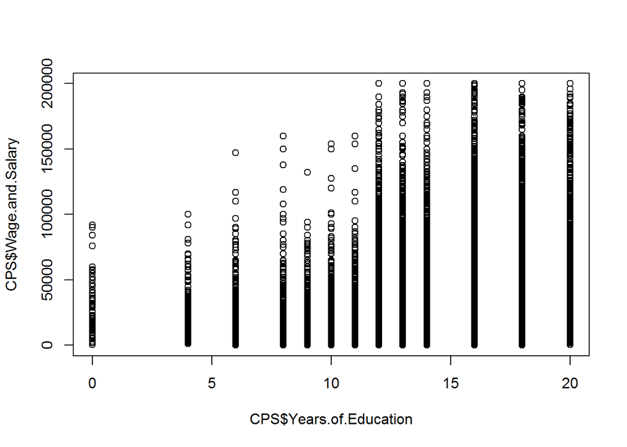

```r
plot(CPS$Years.of.Education,CPS$Wage.and.Salary)
```

Check out this link on EDA: http://www.r-bloggers.com/exploratory-data-analysis-useful-r-functions-for-exploring-a-data-frame/

# Simple Linear Regression

The starting point for linear regression analysis is the assumption that the relationship between the target and the predictor(s) variables is best represented by a line. The functional form of a simple linear regression model is as follows:

Y(i)=B(0)+B(1)*X+E(i)

Where,

Y(i) is the target (i.e. outcome) for observation i

B(0) is the y-intercept, which shows what Y_i is equal to when there is no predictor variable X

B(1) is the slope, or how much Y_i changes when there is a one unit change in the predictor variable X

X is the predictor variable

E(i) is the error term, or the remaining variability in the target Y that is not explained by the predictor X

# Ordinary Least Squares

In a simple linear regression model, we do not know the value of B because we do not have all the data points for the entire population. We are usually working with a sample (i.e. some number of data points from the population of interest). Consequently, we have to come up with an estimate for B. The most common estimation method is called ordinary least squares (OLS).

The OLS method chooses the value of B so as to minimize the residual sum of squares (RSS). The RSS is the sum of the squared values of the residuals. Each residual is the difference between the actual target value and the estimated target value.

e(i)=Y(i)-Yhat(i) Where, e(i) = residual Y(i) = actual target value Yhat(i) = predicted/estimated target value

Minimizes RSS = e(1)^2 + e(2)^2 + … + e(n)^2

# Model 1: Does Educational Attainment Matter?

```r
Model.1<-lm(Wage.and.Salary~Years.of.Education,data=CPS)
summary(Model.1)
```

```
##
## Call:
## lm(formula = Wage.and.Salary ~ Years.of.Education, data = CPS)
##
## Residuals:
##    Min     1Q Median     3Q    Max
## -75479 -21042  -5655  14570 166570
##
## Coefficients:
##                     Estimate Std. Error t value Pr(>|t|)
## (Intercept)        -30243.26     643.44   -47.0   <2e-16 ***
## Years.of.Education   5306.11      45.88   115.7   <2e-16 ***
## ---
## Signif. codes:  0 '***' 0.001 '**' 0.01 '*' 0.05 '.' 0.1 ' ' 1
##
## Residual standard error: 31380 on 60312 degrees of freedom
## Multiple R-squared:  0.1815, Adjusted R-squared:  0.1815
## F-statistic: 1.338e+04 on 1 and 60312 DF,  p-value: < 2.2e-16
```

# Interpreting Model 1

Questions to answer:

1. On average, how much Wage.and.Salary change for every additional year of educational attainment?
2. Is the coefficient of Years.of.Education significantly different from zero?
3. What’s the y-intercept? Why does that even matter?
4. How well does Years.of.Education explain Wage.and.Salary? (i.e. Goodness of Fit)

# Explaining the Statistical Significance of Educational Attainment (i.e. the observed relationship is not by chance!)

The hypothesis test we are conducting for educational attainment is as follows:

H0: Years.of.Education does not explain Wage.and.Salary (B = 0)

H1: Years.of.Education does explain Wage.and.Salary (B IS NOT EQUAL to 0)

**If p-value < level of significance, you reject the null hypothesis (H0). Otherwise, you fail to reject H0.**

# Visualizing Model 1

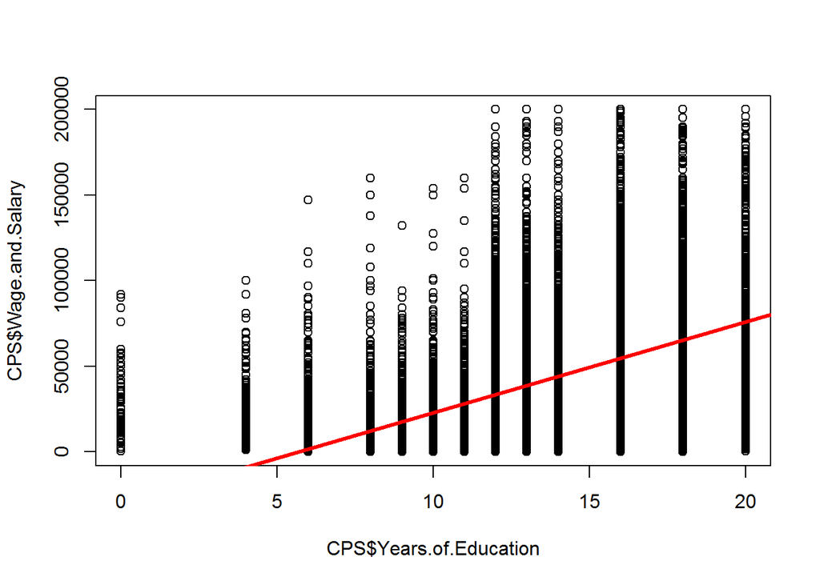

```r
plot(CPS$Years.of.Education,CPS$Wage.and.Salary)
abline(Model.1,lwd=3,col="red")
```

# Assumptions of the Linear Regression Model

1. **No Autocorrelation**: Error values (e) are statistically independent. This assumption is typically violated when you are working with time series data.
2. **Normality of Error Distribution**: The probability distribution of the errors is normal.
3. **Homoskedasticity**: The probability distribution of the errors has constant variance. When this assumption is violated, it is called heteroscedasticity.
4. **Linearity and Additive**: The underlying relationship between the x variable and the y variable is linear. Furthermore, the effects of x’s on y is additive.

Good link with additional information: http://people.duke.edu/~rnau/testing.htm

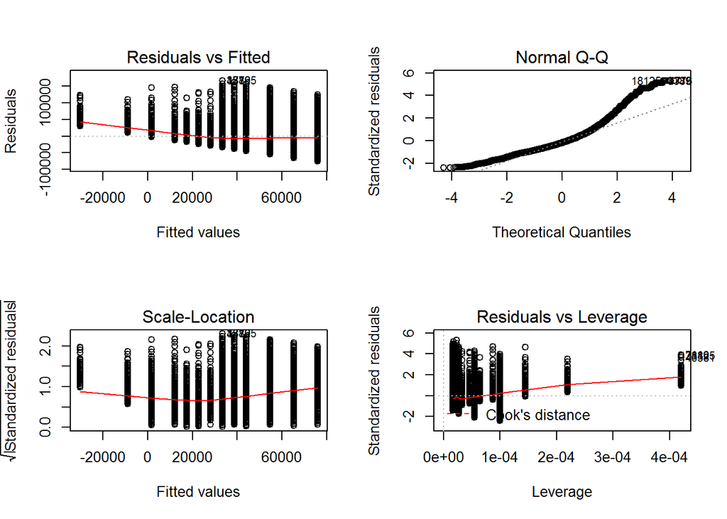

```r
par(mfrow=c(2,2)) #Sets the parameters to put the 4 following plots on the same page
plot(Model.1)
```

**Residual vs Fitted Plot**-The plotted values should look random (i.e. no pattern). If the plot shows a curvilinear relationship, then assumption #4 (linearity) is violated.

**Normal Q-Q Plot**-The plotted values should be a straight line. If it is curved (an S shape), then assumption #2 (normality of errors) is violated.

**Scale-Location Plot**-This plot is a repeat of the Residuals vs. Fitted Plot but on a different scale. The square root of the standardized residuals are plotted against the fitted values. The standardized residuals should look random. If there is a pattern, then assumption #3 (homoskedasticity) is violated.

**Residuals vs. Leverage**-This plot highlights the outlier values of the target variable (Y) that have the highest effect on the parameter estimates. These are called “high influence” points. Look for values outside of the Cook’s distance (red dashed line).

# Diagnostic Tests

There are other ways to check for some of the assumptions of linear regression.

**Checking for No Autocorrelation (assumption #1)**: Use Durbin Watson statistic.

DW statistic close to 2 means there is no autocorrelation.  
Closer to 0 means positive autocorrelation.  
Closer to 4 means negative autocorrelation.

H0: There is no autocorrelation.

H1: There is autocorrelation.

```r
library(car)
durbinWatsonTest(Model.1)
```

```
##  lag Autocorrelation D-W Statistic p-value
##    1      0.05614103      1.887656       0
##  Alternative hypothesis: rho != 0
```

**Checking for Homoskedasticity**

H0: Errors have constant variance (homoskedasticity)

H1: Errors do not have constant variance (heteroskedasticity)

```r
ncvTest(Model.1)
```

```
## Non-constant Variance Score Test
## Variance formula: ~ fitted.values
## Chisquare = 4818.237    Df = 1     p = 0
```

# Model 2: Does Sex Matter Too?

We discovered so far that educational attainment does matter. Let’s extend our model! What about sex? When we consider more than one predictor, our simple linear regression model transforms into **multiple** linear regression model.

The functional form of the multiple linear regression model is as follows:

Y(i)=B(0) + B(1)* X(1) + B(2) * X(2) + B(3) * X(3)+ … +B(k) * X(k) + E(i)

Where,

Y(i) is the target (i.e. outcome) for observation i

B(0) is the y-intercept, which shows what Y_i is equal to when there are no predictors

B(k) is the slope, or how much Y(i) changes when there is a one unit change in the predictor variable X(k)

X(k) is a predictor variable

E(i) is the error term, or the remaining variability in the target Y that is not explained by the predictors

When we extend the case to multiple linear regression models, we fit them the same way as we do with the simple linear regression models. We still want to find values of B’s that minimize the sum of squared residuals. (Instead of finding the best fitting line, we are now looking for the best fitting plane in a multi-dimensional space.)

```r
CPS$Sex<-relevel(CPS$Sex,ref="Male") #Using male as our base for comparison
Model.2<-lm(Wage.and.Salary~Years.of.Education+Sex,data=CPS)
summary(Model.2)
```

```
##
## Call:
## lm(formula = Wage.and.Salary ~ Years.of.Education + Sex, data = CPS)
##
## Residuals:
##    Min     1Q Median     3Q    Max
## -84305 -19989  -4989  13825 169493
##
## Coefficients:
##                     Estimate Std. Error t value Pr(>|t|)
## (Intercept)        -25565.12     627.60  -40.73   <2e-16 ***
## Years.of.Education   5518.48      44.56  123.84   <2e-16 ***
## SexFemale          -15667.73     248.31  -63.10   <2e-16 ***
## ---
## Signif. codes:  0 '***' 0.001 '**' 0.01 '*' 0.05 '.' 0.1 ' ' 1
##
## Residual standard error: 30390 on 60311 degrees of freedom
## Multiple R-squared:  0.2322, Adjusted R-squared:  0.2322
## F-statistic:  9121 on 2 and 60311 DF,  p-value: < 2.2e-16
```

Questions to answer:

1. Does educational attainment matter? How much does it matter?
2. Does sex matter? How much more do men earn, on average, compare to women?
3. What is the goodness of fit of the model?

# Sex as a Dummy Variable

# Is Model 2 Significant? (Using the Overall F Test)

When we are incorporating more than one predictor, we need to ask this question: “Are all the regression coefficients zero?” In another word, we are testing to see whether ANY predictor explain the variation in the target variable. To do so, we conduct the overall F-test.

H0: There is no relationship between any of the predictor and the target variable. [B(1)=B(2)=0]

H1: There is a relationship between at least one predictor and the target variable. (At least one B(j) IS NOT EQUAL to 0]

Refer to your summary output above.

# Model 3: Does Having Underage Child(ren) Matter?

```r
Model.3<-lm(Wage.and.Salary~Years.of.Education+Sex+Child.Under.18, data=CPS)
summary(Model.3)
```

```
##
## Call:
## lm(formula = Wage.and.Salary ~ Years.of.Education + Sex + Child.Under.18,
##     data = CPS)
##
## Residuals:
##    Min     1Q Median     3Q    Max
## -82839 -19736  -4836  13539 167912
##
## Coefficients:
##                     Estimate Std. Error t value Pr(>|t|)
## (Intercept)        -27579.48     644.56  -42.79   <2e-16 ***
## Years.of.Education   5545.94      44.54  124.51   <2e-16 ***
## SexFemale          -15735.61     248.00  -63.45   <2e-16 ***
## Child.Under.18Yes    3305.81     247.44   13.36   <2e-16 ***
## ---
## Signif. codes:  0 '***' 0.001 '**' 0.01 '*' 0.05 '.' 0.1 ' ' 1
##
## Residual standard error: 30350 on 60310 degrees of freedom
## Multiple R-squared:  0.2345, Adjusted R-squared:  0.2345
## F-statistic:  6158 on 3 and 60310 DF,  p-value: < 2.2e-16
```

# Model 4: Maybe Having Underage Child(ren) Affect Men and Women Differently?

We can gauge the differences using **interaction terms**. Sex * Child.Under.18 is an interaction term.

```r
Model.4<-lm(Wage.and.Salary~Years.of.Education+Sex+Child.Under.18+Sex:Child.Under.18, data=CPS)
summary(Model.4)
```

```
##
## Call:
## lm(formula = Wage.and.Salary ~ Years.of.Education + Sex + Child.Under.18 +
##     Sex:Child.Under.18, data = CPS)
##
## Residuals:
##    Min     1Q Median     3Q    Max
## -84477 -19644  -4890  13527 170178
##
## Coefficients:
##                              Estimate Std. Error t value Pr(>|t|)
## (Intercept)                 -29815.39     654.27  -45.57   <2e-16 ***
## Years.of.Education            5550.39      44.42  124.95   <2e-16 ***
## SexFemale                   -11170.91     351.15  -31.81   <2e-16 ***
## Child.Under.18Yes             7684.68     343.62   22.36   <2e-16 ***
## SexFemale:Child.Under.18Yes  -9031.30     493.22  -18.31   <2e-16 ***
## ---
## Signif. codes:  0 '***' 0.001 '**' 0.01 '*' 0.05 '.' 0.1 ' ' 1
##
## Residual standard error: 30260 on 60309 degrees of freedom
## Multiple R-squared:  0.2387, Adjusted R-squared:  0.2387
## F-statistic:  4728 on 4 and 60309 DF,  p-value: < 2.2e-16
```

# Model 5: Hey, What About Work Experience?

```r
Model.5<-lm(Wage.and.Salary~Years.of.Education+Sex+Child.Under.18+Sex:Child.Under.18+Years.of.Potential.Work.Experience, data=CPS)
summary(Model.5)
```

```
##
## Call:
## lm(formula = Wage.and.Salary ~ Years.of.Education + Sex + Child.Under.18 +
##     Sex:Child.Under.18 + Years.of.Potential.Work.Experience,
##     data = CPS)
##
## Residuals:
##    Min     1Q Median     3Q    Max
## -97049 -18102  -4278  12569 178071
##
## Coefficients:
##                                      Estimate Std. Error t value Pr(>|t|)
## (Intercept)                        -48216.246    703.150  -68.57   <2e-16
## Years.of.Education                   5877.652     43.446  135.29   <2e-16
## SexFemale                          -11936.904    341.049  -35.00   <2e-16
## Child.Under.18Yes                   10295.366    336.247   30.62   <2e-16
## Years.of.Potential.Work.Experience    550.231      9.029   60.94   <2e-16
## SexFemale:Child.Under.18Yes         -7373.827    479.474  -15.38   <2e-16
##
## (Intercept)                        ***
## Years.of.Education                 ***
## SexFemale                          ***
## Child.Under.18Yes                  ***
## Years.of.Potential.Work.Experience ***
## SexFemale:Child.Under.18Yes        ***
## ---
## Signif. codes:  0 '***' 0.001 '**' 0.01 '*' 0.05 '.' 0.1 ' ' 1
##
## Residual standard error: 29370 on 60308 degrees of freedom
## Multiple R-squared:  0.2829, Adjusted R-squared:  0.2828
## F-statistic:  4758 on 5 and 60308 DF,  p-value: < 2.2e-16
```

# Model 6: What If the Relationship between Work Experience and Wage.and.Salary is not Linear?

If the relationship between the predictor and target variables is not linear, then a simple solution is to use non-linear transformations of the predictors. We can square, cube, take the square root, or log of the predictor variable(s).

```r
Model.6.a<-lm(Wage.and.Salary~Years.of.Education+Sex+Child.Under.18+Sex:Child.Under.18+Years.of.Potential.Work.Experience+I(Years.of.Potential.Work.Experience^2), data=CPS)
summary(Model.6.a) #quadratic
```

```
##
## Call:
## lm(formula = Wage.and.Salary ~ Years.of.Education + Sex + Child.Under.18 +
##     Sex:Child.Under.18 + Years.of.Potential.Work.Experience +
##     I(Years.of.Potential.Work.Experience^2), data = CPS)
##
## Residuals:
##    Min     1Q Median     3Q    Max
## -88523 -17735  -4145  12126 183822
##
## Coefficients:
##                                           Estimate Std. Error t value
## (Intercept)                             -53296.629    700.025  -76.14
## Years.of.Education                        5579.609     43.199  129.16
## SexFemale                               -11702.973    335.294  -34.90
## Child.Under.18Yes                         7308.901    336.888   21.70
## Years.of.Potential.Work.Experience        1836.273     29.412   62.43
## I(Years.of.Potential.Work.Experience^2)    -26.556      0.579  -45.86
## SexFemale:Child.Under.18Yes              -7183.655    471.347  -15.24
##                                         Pr(>|t|)
## (Intercept)                               <2e-16 ***
## Years.of.Education                        <2e-16 ***
## SexFemale                                 <2e-16 ***
## Child.Under.18Yes                         <2e-16 ***
## Years.of.Potential.Work.Experience        <2e-16 ***
## I(Years.of.Potential.Work.Experience^2)   <2e-16 ***
## SexFemale:Child.Under.18Yes               <2e-16 ***
## ---
## Signif. codes:  0 '***' 0.001 '**' 0.01 '*' 0.05 '.' 0.1 ' ' 1
##
## Residual standard error: 28870 on 60307 degrees of freedom
## Multiple R-squared:  0.3071, Adjusted R-squared:  0.307
## F-statistic:  4454 on 6 and 60307 DF,  p-value: < 2.2e-16
```

```r
Model.6.b<-lm(Wage.and.Salary~Years.of.Education+Sex+Child.Under.18+Sex:Child.Under.18+poly(Years.of.Potential.Work.Experience,3),data=CPS)
summary(Model.6.b)
```

```
##
## Call:
## lm(formula = Wage.and.Salary ~ Years.of.Education + Sex + Child.Under.18 +
##     Sex:Child.Under.18 + poly(Years.of.Potential.Work.Experience,
##     3), data = CPS)
##
## Residuals:
##    Min     1Q Median     3Q    Max
## -87632 -17642  -4038  12104 184797
##
## Coefficients:
##                                                Estimate Std. Error t value
## (Intercept)                                  -2.941e+04  6.437e+02  -45.68
## Years.of.Education                            5.539e+03  4.321e+01  128.16
## SexFemale                                    -1.146e+04  3.351e+02  -34.19
## Child.Under.18Yes                             6.702e+03  3.388e+02   19.78
## poly(Years.of.Potential.Work.Experience, 3)1  1.729e+06  2.996e+04   57.71
## poly(Years.of.Potential.Work.Experience, 3)2 -1.405e+06  3.009e+04  -46.70
## poly(Years.of.Potential.Work.Experience, 3)3  4.312e+05  2.946e+04   14.63
## SexFemale:Child.Under.18Yes                  -7.461e+03  4.709e+02  -15.85
##                                              Pr(>|t|)
## (Intercept)                                    <2e-16 ***
## Years.of.Education                             <2e-16 ***
## SexFemale                                      <2e-16 ***
## Child.Under.18Yes                              <2e-16 ***
## poly(Years.of.Potential.Work.Experience, 3)1   <2e-16 ***
## poly(Years.of.Potential.Work.Experience, 3)2   <2e-16 ***
## poly(Years.of.Potential.Work.Experience, 3)3   <2e-16 ***
## SexFemale:Child.Under.18Yes                    <2e-16 ***
## ---
## Signif. codes:  0 '***' 0.001 '**' 0.01 '*' 0.05 '.' 0.1 ' ' 1
##
## Residual standard error: 28820 on 60306 degrees of freedom
## Multiple R-squared:  0.3095, Adjusted R-squared:  0.3094
## F-statistic:  3862 on 7 and 60306 DF,  p-value: < 2.2e-16
```

# Model 7: Qualitative Variable as Predictor

Take a look at Class.of.Worker variable. Individual belongs to one of the following classes:

-Private Sector

-Federal Government

-State Government

-Local Government

-Self Employed, Incorporated Business

-Self Employed, Not Incorporated Business

We include a qualitative variable into a regression model by creating dummy variables.

```r
Model.7<-lm(Wage.and.Salary~Years.of.Education+Sex+Child.Under.18+Sex:Child.Under.18+Years.of.Potential.Work.Experience+Class.of.Worker, data=CPS)
summary(Model.7)
```

```
##
## Call:
## lm(formula = Wage.and.Salary ~ Years.of.Education + Sex + Child.Under.18 +
##     Sex:Child.Under.18 + Years.of.Potential.Work.Experience +
##     Class.of.Worker, data = CPS)
##
## Residuals:
##     Min      1Q  Median      3Q     Max
## -103698  -17921   -4215   12481  177503
##
## Coefficients:
##                                                Estimate Std. Error t value
## (Intercept)                                   -35941.47    1027.55 -34.978
## Years.of.Education                              5895.23      44.26 133.200
## SexFemale                                     -11476.18     339.50 -33.803
## Child.Under.18Yes                              10389.43     333.71  31.133
## Years.of.Potential.Work.Experience               544.97       9.05  60.217
## Class.of.WorkerLocal Govt                     -17125.73     810.81 -21.122
## Class.of.WorkerPrivate                        -12479.51     705.38 -17.692
## Class.of.WorkerSelf Employed Incorporated      -5693.76     928.30  -6.134
## Class.of.WorkerSelf Employed Not Incorporated -34383.79    1397.20 -24.609
## Class.of.WorkerState Govt                     -17284.05     868.38 -19.904
## SexFemale:Child.Under.18Yes                    -7357.73     475.74 -15.466
##                                               Pr(>|t|)
## (Intercept)                                    < 2e-16 ***
## Years.of.Education                             < 2e-16 ***
## SexFemale                                      < 2e-16 ***
## Child.Under.18Yes                              < 2e-16 ***
## Years.of.Potential.Work.Experience             < 2e-16 ***
## Class.of.WorkerLocal Govt                      < 2e-16 ***
## Class.of.WorkerPrivate                         < 2e-16 ***
## Class.of.WorkerSelf Employed Incorporated     8.65e-10 ***
## Class.of.WorkerSelf Employed Not Incorporated  < 2e-16 ***
## Class.of.WorkerState Govt                      < 2e-16 ***
## SexFemale:Child.Under.18Yes                    < 2e-16 ***
## ---
## Signif. codes:  0 '***' 0.001 '**' 0.01 '*' 0.05 '.' 0.1 ' ' 1
##
## Residual standard error: 29140 on 60303 degrees of freedom
## Multiple R-squared:  0.2942, Adjusted R-squared:  0.2941
## F-statistic:  2514 on 10 and 60303 DF,  p-value: < 2.2e-16
```

Question: What is the “base” class of worker R chose for comparison purpose?

We can change the “base” class of worker for comparison purpose too!

```r
CPS$Class.of.Worker<-relevel(CPS$Class.of.Worker,ref="Private") #Using private as our base for comparison
Model.7<-lm(Wage.and.Salary~Years.of.Education+Sex+Child.Under.18+Sex:Child.Under.18+Years.of.Potential.Work.Experience+Class.of.Worker, data=CPS)
summary(Model.7)
```

```
##
## Call:
## lm(formula = Wage.and.Salary ~ Years.of.Education + Sex + Child.Under.18 +
##     Sex:Child.Under.18 + Years.of.Potential.Work.Experience +
##     Class.of.Worker, data = CPS)
##
## Residuals:
##     Min      1Q  Median      3Q     Max
## -103698  -17921   -4215   12481  177503
##
## Coefficients:
##                                                Estimate Std. Error t value
## (Intercept)                                   -48420.98     705.89 -68.596
## Years.of.Education                              5895.23      44.26 133.200
## SexFemale                                     -11476.18     339.50 -33.803
## Child.Under.18Yes                              10389.43     333.71  31.133
## Years.of.Potential.Work.Experience               544.97       9.05  60.217
## Class.of.WorkerFederal Govt                    12479.51     705.38  17.692
## Class.of.WorkerLocal Govt                      -4646.22     453.37 -10.248
## Class.of.WorkerSelf Employed Incorporated       6785.74     642.27  10.565
## Class.of.WorkerSelf Employed Not Incorporated -21904.28    1223.55 -17.902
## Class.of.WorkerState Govt                      -4804.54     551.36  -8.714
## SexFemale:Child.Under.18Yes                    -7357.73     475.74 -15.466
##                                               Pr(>|t|)
## (Intercept)                                     <2e-16 ***
## Years.of.Education                              <2e-16 ***
## SexFemale                                       <2e-16 ***
## Child.Under.18Yes                               <2e-16 ***
## Years.of.Potential.Work.Experience              <2e-16 ***
## Class.of.WorkerFederal Govt                     <2e-16 ***
## Class.of.WorkerLocal Govt                       <2e-16 ***
## Class.of.WorkerSelf Employed Incorporated       <2e-16 ***
## Class.of.WorkerSelf Employed Not Incorporated   <2e-16 ***
## Class.of.WorkerState Govt                       <2e-16 ***
## SexFemale:Child.Under.18Yes                     <2e-16 ***
## ---
## Signif. codes:  0 '***' 0.001 '**' 0.01 '*' 0.05 '.' 0.1 ' ' 1
##
## Residual standard error: 29140 on 60303 degrees of freedom
## Multiple R-squared:  0.2942, Adjusted R-squared:  0.2941
## F-statistic:  2514 on 10 and 60303 DF,  p-value: < 2.2e-16
```

# Model 8: Maybe All the Predictors Matter?

```r
Model.8<-lm(Wage.and.Salary~.,data=CPS)
summary(Model.8)
```

```
##
## Call:
## lm(formula = Wage.and.Salary ~ ., data = CPS)
##
## Residuals:
##    Min     1Q Median     3Q    Max
## -98213 -16622  -3613  11207 186498
##
## Coefficients:
##                                                                          Estimate
## (Intercept)                                                            -40208.497
## Years.of.Education                                                       5312.292
## Years.of.Potential.Work.Experience                                        417.185
## Class.of.WorkerFederal Govt                                              5913.058
## Class.of.WorkerLocal Govt                                               -5776.282
## Class.of.WorkerSelf Employed Incorporated                                8237.520
## Class.of.WorkerSelf Employed Not Incorporated                          -18746.657
## Class.of.WorkerState Govt                                               -6066.511
## Census.RegionEast South Central                                         -3691.109
## Census.RegionMiddle Atlantic                                             2565.825
## Census.RegionMountain                                                     797.052
## Census.RegionNew England                                                 3323.824
## Census.RegionPacific                                                     3497.058
## Census.RegionSouth Atlantic                                              1051.175
## Census.RegionWest North Central                                          -845.249
## Census.RegionWest South Central                                           526.425
## Work.StatusPart-time                                                   -23194.342
## Industry.of.WorkArts, Entertainment, Recreation, Accommodation            432.031
## Industry.of.WorkConstruction                                             5294.185
## Industry.of.WorkEducational, Health, and Social Services                 2841.324
## Industry.of.WorkFinancial, Insurance, Real Estate, Rental, and Leasing  11708.955
## Industry.of.WorkInformation                                             12881.688
## Industry.of.WorkManufacturing                                           10600.005
## Industry.of.WorkMining                                                  27589.358
## Industry.of.WorkOther Services But Not Public Administration             -548.901
## Industry.of.WorkProfessional, Scientific, Management, Administration    10271.107
## Industry.of.WorkPublic Administration                                   14053.456
## Industry.of.WorkTransportation and Utilities                             8558.180
## Industry.of.WorkWholesale or Retail Trade                                2058.650
## Child.Under.18Yes                                                        6071.559
```

[output cut: 120 more lines]

```
## Industry.of.WorkManufacturing                                          ***
## Industry.of.WorkMining                                                 ***
## Industry.of.WorkOther Services But Not Public Administration
## Industry.of.WorkProfessional, Scientific, Management, Administration   ***
## Industry.of.WorkPublic Administration                                  ***
## Industry.of.WorkTransportation and Utilities                           ***
## Industry.of.WorkWholesale or Retail Trade                              *
## Child.Under.18Yes                                                      ***
## SexFemale                                                              ***
## ---
## Signif. codes:  0 '***' 0.001 '**' 0.01 '*' 0.05 '.' 0.1 ' ' 1
##
## Residual standard error: 27120 on 60283 degrees of freedom
## Multiple R-squared:  0.3888, Adjusted R-squared:  0.3885
## F-statistic:  1278 on 30 and 60283 DF,  p-value: < 2.2e-16
```

Questions:

1. Can you pick out the dummy variables?
2. What predictors matter?
3. What is the goodness of fit?

# Model 9: All the Predictors and an Interaction Term

```r
Model.9<-lm(Wage.and.Salary~.+Sex:Child.Under.18,data=CPS)
summary(Model.9)
```

```
##
## Call:
## lm(formula = Wage.and.Salary ~ . + Sex:Child.Under.18, data = CPS)
##
## Residuals:
##    Min     1Q Median     3Q    Max
## -99433 -16490  -3645  11163 184954
##
## Coefficients:
##                                                                          Estimate
## (Intercept)                                                            -41332.648
## Years.of.Education                                                       5310.286
## Years.of.Potential.Work.Experience                                        412.322
## Class.of.WorkerFederal Govt                                              6023.175
## Class.of.WorkerLocal Govt                                               -5777.865
## Class.of.WorkerSelf Employed Incorporated                                8271.415
## Class.of.WorkerSelf Employed Not Incorporated                          -18601.437
## Class.of.WorkerState Govt                                               -6073.667
## Census.RegionEast South Central                                         -3703.251
## Census.RegionMiddle Atlantic                                             2550.039
## Census.RegionMountain                                                     779.968
## Census.RegionNew England                                                 3323.908
## Census.RegionPacific                                                     3469.675
## Census.RegionSouth Atlantic                                              1047.019
## Census.RegionWest North Central                                          -843.570
## Census.RegionWest South Central                                           576.891
## Work.StatusPart-time                                                   -23048.603
## Industry.of.WorkArts, Entertainment, Recreation, Accommodation            499.171
## Industry.of.WorkConstruction                                             5219.289
## Industry.of.WorkEducational, Health, and Social Services                 2949.891
## Industry.of.WorkFinancial, Insurance, Real Estate, Rental, and Leasing  11717.808
## Industry.of.WorkInformation                                             12844.597
## Industry.of.WorkManufacturing                                           10583.217
## Industry.of.WorkMining                                                  27500.110
## Industry.of.WorkOther Services But Not Public Administration             -545.886
## Industry.of.WorkProfessional, Scientific, Management, Administration    10310.176
## Industry.of.WorkPublic Administration                                   14010.506
## Industry.of.WorkTransportation and Utilities                             8582.499
## Industry.of.WorkWholesale or Retail Trade                                2063.982
## Child.Under.18Yes                                                        8551.219
```

[output cut: 125 more lines]

```
## Industry.of.WorkMining                                                 ***
## Industry.of.WorkOther Services But Not Public Administration
## Industry.of.WorkProfessional, Scientific, Management, Administration   ***
## Industry.of.WorkPublic Administration                                  ***
## Industry.of.WorkTransportation and Utilities                           ***
## Industry.of.WorkWholesale or Retail Trade                              *
## Child.Under.18Yes                                                      ***
## SexFemale                                                              ***
## Child.Under.18Yes:SexFemale                                            ***
## ---
## Signif. codes:  0 '***' 0.001 '**' 0.01 '*' 0.05 '.' 0.1 ' ' 1
##
## Residual standard error: 27090 on 60282 degrees of freedom
## Multiple R-squared:  0.3902, Adjusted R-squared:  0.3899
## F-statistic:  1244 on 31 and 60282 DF,  p-value: < 2.2e-16
```

# Which Model is “Better”? Comparing Two Models Using the Partial F-Test

We want to know whether adding in this interaction term makes the “full model” statistically significantly different from the “reduced model” (i.e. no interaction term). We can answer this question via a partial F-test.

H0: The full model is not statistically significant. We should use the reduced model.

H1: The full model is statistically significant. We should use the full model.

```r
anova(Model.8,Model.9)
```

```
## Analysis of Variance Table
##
## Model 1: Wage.and.Salary ~ Years.of.Education + Years.of.Potential.Work.Experience +
##     Class.of.Worker + Census.Region + Work.Status + Industry.of.Work +
##     Child.Under.18 + Sex
## Model 2: Wage.and.Salary ~ Years.of.Education + Years.of.Potential.Work.Experience +
##     Class.of.Worker + Census.Region + Work.Status + Industry.of.Work +
##     Child.Under.18 + Sex + Sex:Child.Under.18
##   Res.Df        RSS Df  Sum of Sq      F    Pr(>F)
## 1  60283 4.4341e+13
## 2  60282 4.4241e+13  1 1.0014e+11 136.45 < 2.2e-16 ***
## ---
## Signif. codes:  0 '***' 0.001 '**' 0.01 '*' 0.05 '.' 0.1 ' ' 1
```

# A Problem with Multiple Linear Regression Model: Multicollinearity

Collinearity occurs when two predictor variables are closely related to one another. That is, two predictors tend to increase or decrease together. Multicollinearity occurs when there is collinearity between three or more predictor variables. Collinearity/multicollinearity makes it difficult to distinguish the individual effect of each predictor variable on the target variable. As a result, the accuracy of the estimated regression coefficients is reduced. Furthermore, the standard error of each estimated regression coefficient increases. Because the t-statistic is calculated by dividing the estimated regression coefficient by its estimated standard error, collinearity/multicollinearity reduces the t-statistic. As a result, we are more likely to fail to reject the null hypothesis (H0: Beta = 0). The power of the hypothesis test is reduced by the presence of collinearity/multicollinearity.

One way to assess multicollinearity is to compute the variance inflation factor (VIF) for each predictor.

The smallest VIF is 1, which is equivalent to no multicollinearity. A VIF of 2 is equivalent to saying that you need a sample size twice as large as your current sample size to overcome the multicollinearity in the model. James et al. (2013) noted that some experts believe a VIF greater than 5 indicates serious multicollinearity (page 101).

The alternative to collecting more data (usually not possible!) is to exclude some of the highly correlated predictors.

```r
library(car)
vif(Model.9)
```

```
##                                        GVIF Df GVIF^(1/(2*Df))
## Years.of.Education                 1.242918  1        1.114862
## Years.of.Potential.Work.Experience 1.149993  1        1.072377
## Class.of.Worker                    1.767596  5        1.058616
## Census.Region                      1.063144  8        1.003834
## Work.Status                        1.131951  1        1.063932
## Industry.of.Work                   2.456047 12        1.038149
## Child.Under.18                     1.990276  1        1.410772
## Sex                                2.186804  1        1.478785
## Child.Under.18:Sex                 3.019967  1        1.737805
```

# Using Model.9 to Make Predictions

Let’s assume that we want to predict wage/salary for a person with the following characteristics.

```r
Person.1=data.frame(Years.of.Education=20,Years.of.Potential.Work.Experience=7,Class.of.Worker="Private",Census.Region="West North Central", Work.Status="Full-time", Industry.of.Work="Educational, Health, and Social Services",Child.Under.18="Yes",Sex="Female")

predict(Model.9,Person.1,interval="prediction")
```

```
##       fit      lwr      upr
## 1 65641.1 12534.91 118747.3
```

# Logistic Regression: Or How Target Predicts Pregnant Customers

Remember when we found out that Target was predicting which of its customers were pregnant? If you have not read Eric Siegel’s “Predictive Analytics”, then read this: http://www.nytimes.com/2012/02/19/magazine/shopping-habits.html?_r=0

So far, we have only looked at regression models where the target variable is continuous. Sometimes, we are interested in predicting a qualitative response. For example, whether a potential customer is likely to “be pregnant” or “not pregnant”. This is a process known as classification. There are many classification models. Here we look at a regression approach to classification. This model is called a logistic regression.

We fit the logistic regression using maximum likelihood. The idea behind maximum likelihood is that we seek estimates for B’s such that the predicted probability corresponds as closely as possible to the observed data. See here for more details:

https://en.wikipedia.org/wiki/Maximum_likelihood

Also refer to Section 4.3.2 in **James et al.** (page 133).

The dataset we discuss below is from Foreman, John W. (2014). **Data Smart: Using Data Science to Transform Information into Insight**. Indianapolis, IN: Wiley. ISBN: 978-1-118-66146-8.

```r
Target<-read.csv(file="C:/Users/PhamX/Courses/Spring_2017/BIA_6301/Module_1/data/Target_Pregnancy.csv")

str(Target)
```

```
## 'data.frame':    1000 obs. of  18 variables:
##  $ Implied.Gender        : Factor w/ 3 levels "F","M","U": 2 2 2 3 1 1 2 1 1 1 ...
##  $ Home.Apt..PO.Box      : Factor w/ 3 levels "A","H","P": 1 2 2 2 1 2 2 2 2 2 ...
##  $ Pregnancy.Test        : int  1 1 1 0 0 0 0 0 0 0 ...
##  $ Birth.Control         : int  0 0 0 0 0 0 1 0 0 0 ...
##  $ Feminine.Hygiene      : int  0 0 0 0 0 0 0 0 0 0 ...
##  $ Folic.Acid            : int  0 0 0 0 0 0 1 0 0 0 ...
##  $ Prenatal.Vitamins     : int  1 1 0 0 0 1 1 0 0 1 ...
##  $ Prenatal.Yoga         : int  0 0 0 0 1 0 0 0 0 0 ...
##  $ Body.Pillow           : int  0 0 0 0 0 0 0 0 0 0 ...
##  $ Ginger.Ale            : int  0 0 0 1 0 0 0 0 1 0 ...
##  $ Sea.Bands             : int  0 0 1 0 0 0 0 0 0 0 ...
##  $ Stopped.buying.ciggies: int  0 0 0 0 0 1 0 0 0 0 ...
##  $ Cigarettes            : int  0 0 0 0 0 0 0 0 0 0 ...
##  $ Smoking.Cessation     : int  0 0 0 0 0 0 0 0 0 0 ...
##  $ Stopped.buying.wine   : int  0 0 0 0 1 0 0 0 0 0 ...
##  $ Wine                  : int  0 0 0 0 0 0 0 0 0 0 ...
##  $ Maternity.Clothes     : int  0 0 0 0 0 0 0 1 0 1 ...
##  $ PREGNANT              : int  1 1 1 1 1 1 1 1 1 1 ...
```

Here are the variables:

Implied.Gender: Account holder is male/female/unknown

Home.Apt..PO.Box: Account holder address is home/apartment/PO box

Pregnancy.Test: Recently purchased a pregnancy test

Birth.Control: Recently purchased birth control

Feminine.Hygiene: Recently purchased feminine hygiene products

Folic.Acid: Recently purchased folic acid supplements

Prenantal.Vitamins: Recently purchased prenatal vitamins

Prenatal.Yoga: Recently purchased prenatal yoga DVD

Body.Pillow: Recently purchased a body pillow

Ginger.Ale: Recently purchased ginger ale

Sea.Bands: Recently purchased Sea.Bands

Stopped.buying.ciggies: Bought cigarettes regularly until recently, then stopped

Cigarettes: Recently purchased cigarettes

Smoking.Cessation: Recently purchased smoking cessation products (gums, patch, etc.)

Stopped.buying.wine: Bought wine regularly until recently, then stopped

Wine: Recently purchased wine

Maternity.Clothes: Recently purchased maternity clothing

Note: Variable descriptions are from page 208 in Foreman (2014).

```r
Target.Model <- glm(PREGNANT~., data=Target, family=binomial()) #Fit a logistic regression
summary(Target.Model)
```

```
##
## Call:
## glm(formula = PREGNANT ~ ., family = binomial(), data = Target)
##
## Deviance Residuals:
##     Min       1Q   Median       3Q      Max
## -3.2012  -0.5566  -0.0246   0.5127   2.8658
##
## Coefficients:
##                         Estimate Std. Error z value Pr(>|z|)
## (Intercept)            -0.343597   0.180755  -1.901 0.057315 .
## Implied.GenderM        -0.453880   0.197566  -2.297 0.021599 *
## Implied.GenderU         0.141939   0.307588   0.461 0.644469
## Home.Apt..PO.BoxH      -0.172927   0.194591  -0.889 0.374180
## Home.Apt..PO.BoxP      -0.002813   0.336432  -0.008 0.993329
## Pregnancy.Test          2.370554   0.521781   4.543 5.54e-06 ***
## Birth.Control          -2.300272   0.365270  -6.297 3.03e-10 ***
## Feminine.Hygiene       -2.028558   0.342398  -5.925 3.13e-09 ***
## Folic.Acid              4.077666   0.761888   5.352 8.70e-08 ***
## Prenatal.Vitamins       2.479469   0.369063   6.718 1.84e-11 ***
## Prenatal.Yoga           2.922974   1.146990   2.548 0.010822 *
## Body.Pillow             1.261037   0.860617   1.465 0.142847
## Ginger.Ale              1.938502   0.426733   4.543 5.55e-06 ***
## Sea.Bands               1.107530   0.673435   1.645 0.100053
## Stopped.buying.ciggies  1.302222   0.342347   3.804 0.000142 ***
## Cigarettes             -1.443022   0.370120  -3.899 9.67e-05 ***
## Smoking.Cessation       1.790779   0.512610   3.493 0.000477 ***
## Stopped.buying.wine     1.383888   0.305883   4.524 6.06e-06 ***
## Wine                   -1.565539   0.348910  -4.487 7.23e-06 ***
## Maternity.Clothes       2.078202   0.329432   6.308 2.82e-10 ***
## ---
## Signif. codes:  0 '***' 0.001 '**' 0.01 '*' 0.05 '.' 0.1 ' ' 1
##
## (Dispersion parameter for binomial family taken to be 1)
##
##     Null deviance: 1386.29  on 999  degrees of freedom
## Residual deviance:  744.11  on 980  degrees of freedom
## AIC: 784.11
##
## Number of Fisher Scoring iterations: 7
```

Buying folic acid vitamins increases the log odds of being pregnant by 4.07. Who speaks in “log odds”?

Let’s change log odds into odd ratios.

```r
exp(cbind(Odds_Ratio=coef(Target.Model))) #Change log odds into odds ratios.
```

```
##                        Odds_Ratio
## (Intercept)             0.7092148
## Implied.GenderM         0.6351587
## Implied.GenderU         1.1525067
## Home.Apt..PO.BoxH       0.8411986
## Home.Apt..PO.BoxP       0.9971912
## Pregnancy.Test         10.7033224
## Birth.Control           0.1002315
## Feminine.Hygiene        0.1315250
## Folic.Acid             59.0075655
## Prenatal.Vitamins      11.9349232
## Prenatal.Yoga          18.5965205
## Body.Pillow             3.5290789
## Ginger.Ale              6.9483345
## Sea.Bands               3.0268718
## Stopped.buying.ciggies  3.6774577
## Cigarettes              0.2362128
## Smoking.Cessation       5.9941220
## Stopped.buying.wine     3.9903865
## Wine                    0.2089753
## Maternity.Clothes       7.9900933
```

Buying folic acid vitamins increases the odds of being pregnant by a factor of 59!

What are other good predictors of being pregnant?

# Is the Logistic Regression Model Statistically Significant?

To see whether the model is statistically significant, we can use anova(). Note below that we should see the residual deviance decreasing with each additional predictor being added to the null model. If the addition of a predictor does not decrease the residual deviance by much, we should consider excluding that predictor from our model.

```r
anova(Target.Model,test="Chisq")
```

```
## Analysis of Deviance Table
##
## Model: binomial, link: logit
##
## Response: PREGNANT
##
## Terms added sequentially (first to last)
##
##
##                        Df Deviance Resid. Df Resid. Dev  Pr(>Chi)
## NULL                                     999    1386.29
## Implied.Gender          2   12.695       997    1373.60 0.0017509 **
## Home.Apt..PO.Box        2    0.155       995    1373.44 0.9252812
## Pregnancy.Test          1   65.740       994    1307.70 5.145e-16 ***
## Birth.Control           1   94.011       993    1213.69 < 2.2e-16 ***
## Feminine.Hygiene        1   55.716       992    1157.98 8.374e-14 ***
## Folic.Acid              1  120.579       991    1037.40 < 2.2e-16 ***
## Prenatal.Vitamins       1   72.452       990     964.95 < 2.2e-16 ***
## Prenatal.Yoga           1   14.797       989     950.15 0.0001197 ***
## Body.Pillow             1    5.004       988     945.14 0.0252832 *
## Ginger.Ale              1   28.672       987     916.47 8.572e-08 ***
## Sea.Bands               1    2.780       986     913.69 0.0954305 .
## Stopped.buying.ciggies  1   25.853       985     887.84 3.684e-07 ***
## Cigarettes              1   16.812       984     871.03 4.126e-05 ***
## Smoking.Cessation       1   19.513       983     851.51 9.994e-06 ***
## Stopped.buying.wine     1   32.657       982     818.86 1.100e-08 ***
## Wine                    1   26.021       981     792.84 3.378e-07 ***
## Maternity.Clothes       1   48.723       980     744.11 2.948e-12 ***
## ---
## Signif. codes:  0 '***' 0.001 '**' 0.01 '*' 0.05 '.' 0.1 ' ' 1
```